# Cost-Benefit Analysis of Electricity Transition Pathways for the Maldives

A Policy Brief for Decision-Makers

Author

International Initiative for Impact Evaluation (3ie)

Published

February 6, 2026

# Executive Summary

**The Bottom Line**

**The Maldives can save over $5.6B** by transitioning away from diesel power to renewable energy. The most cost-effective path is connecting to India’s power grid while building a domestic inter-island electricity network.

## 0.1 The Challenge

The Maldives faces a triple energy crisis:

1. **Unsustainable costs**: The country spends over **$400 million per year** importing diesel fuel to generate electricity—money that leaves the economy permanently.
2. **Climate vulnerability**: As the world’s lowest-lying nation, the Maldives is existentially threatened by climate change, yet currently generates **93% of electricity from fossil fuels**.
3. **Energy insecurity**: Complete dependence on imported diesel means global oil price shocks directly impact Maldivian households and businesses.

## 0.2 What We Analyzed

This study evaluated four different pathways for the Maldives’ electricity future over a 30-year period (2026-2056):

| Pathway | What It Means |
| --- | --- |
| **Business as Usual (BAU)** | Keep using diesel generators with minimal change |
| **Full Integration** | Build an undersea cable to India + connect all islands + add solar |
| **National Grid** | Connect all islands with undersea cables + add solar (no India link) |
| **Islanded Green** | Install solar panels and batteries on each island separately |

## 0.3 The Key Finding

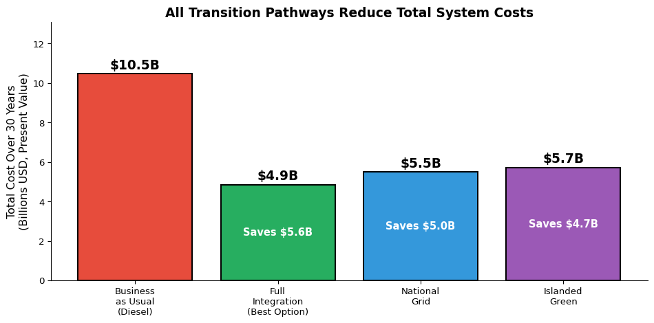

Figure 1: 30-Year Total System Cost by Pathway (Present Value, Billions USD)

**Summary**: If the Maldives continues relying on diesel (“Business as Usual”), the electricity system will cost approximately **$10.5B** over the next 30 years. By contrast, connecting to India and building a national grid (“Full Integration”) would cost **$4.9B** — a net saving of **$5.6B**.

# 1 Introduction: Why This Matters

## 1.1 The Maldives Energy Story

The Republic of Maldives is a nation of striking contradictions. Its pristine beaches and crystal waters attract millions of tourists, yet behind this paradise lies an energy system that threatens both its economy and its very existence.

**The current situation is characterised by four structural weaknesses:**

- The Maldives generates **93% of its electricity from imported diesel fuel**
- Electricity costs Maldivians **$0.25-0.35 per kilowatt-hour**—among the highest rates in South Asia
- The country imports **over 400,000 tonnes of diesel annually**, creating massive foreign exchange outflows
- Despite being at the forefront of climate change advocacy, the nation’s electricity sector emits approximately **0.9 million tonnes of CO₂ per year** from power generation alone (total energy-sector emissions including transport are higher, at roughly 1.5 Mt/yr)

This situation is economically wasteful, environmentally damaging, and — as this analysis demonstrates — addressable through available technologies and financing mechanisms.

## 1.2 Why a Transition Is Urgent

Several factors make 2026 a critical decision point:

1. **Falling renewable energy costs**: Solar panels now cost 90% less than in 2010. Battery storage costs have fallen 80% since 2015. These technologies are now cheaper than diesel in most applications.
2. **Rising fuel costs**: Global diesel prices remain volatile, and the long-term trend points upward as extraction becomes more difficult and carbon prices emerge.
3. **Regional opportunities**: India is actively seeking to expand electricity exports, and neighboring countries are building grid connections. The Maldives risks being left behind.
4. **Climate commitments**: The Maldives has pledged net-zero emissions by 2030—an ambitious target that requires immediate action in the power sector.

## 1.3 Purpose of This Analysis

This cost-benefit analysis provides Cabinet-level decision-makers with a clear, evidence-based comparison of four electricity pathways. We have calculated the full lifecycle costs and benefits of each option over 30 years, accounting for:

- Capital investments (building power plants, cables, batteries)
- Ongoing operational costs (maintenance, staffing)
- Fuel and electricity import costs
- Environmental benefits (avoided carbon emissions)
- Energy security implications

The objective is to **identify which pathway delivers reliable, affordable, clean electricity at the lowest total cost to the nation.**

# 2 Understanding the Geography

Before examining the pathways, an understanding of the Maldives’ unique geographic challenge is essential.

## 2.1 Interactive Map of the Maldives

The map below shows all inhabited islands of the Maldives. Each circle represents an island:

- **Size** indicates population (larger circles = more people)
- **Color** indicates solar energy potential (darker red = better for solar panels)

Clicking on any island reveals detailed information. The layer controls can be used to show or hide the proposed grid connections.

[interactive chart not shown]

Figure 2: Interactive Map: Maldives Islands, Solar Resources, and Proposed Grid Infrastructure

## 2.2 The Geographic Challenge

The Maldives presents a unique infrastructure challenge:

- **40 inhabited islands** spread across the Indian Ocean
- **860 kilometers** from the northernmost to southernmost island
- **336,677 people** to serve with electricity
- **Average solar irradiance of 5.6 kWh/m²/day**—among the best in the world for solar power

This geography explains why the Maldives currently relies on diesel: it was simply too expensive to connect scattered islands with cables, so each island got its own diesel generator. But technology costs have changed dramatically, and this analysis shows that interconnection is now the smarter choice.

With this geographic context in mind, we can now examine the four pathways available to the Maldives — each representing a fundamentally different approach to solving the energy challenge that this unique geography creates.

# 3 The Four Pathways Explained

This section explains each of the four options in plain language, including what investments they require and what they would mean for everyday Maldivians.

## 3.1 Pathway 1: Business as Usual (BAU)

**What BAU Means**

Keep doing what we’re doing: run diesel generators on each island with minimal investment in alternatives.

**What happens under BAU:**

- Diesel generators continue operating on each island
- Only minimal solar additions (staying at ~7% renewable)
- No new undersea cables or grid connections
- Continued import of 400,000+ tonnes of diesel annually

**The costs:**

- Over **$27 billion in fuel costs** over 30 years
- Electricity prices remain high ($0.35+/kWh)
- Complete exposure to oil price volatility
- **53.7 million tonnes of CO₂ emissions** from electricity generation alone

**Who wins, who loses:**

- ✅ Diesel importers and generator manufacturers benefit from continued business
- ❌ Consumers pay the highest electricity rates
- ❌ The environment and climate continue to suffer
- ❌ Foreign exchange reserves drain to pay for fuel imports

**Assessment:** BAU is the most expensive option over the analysis horizon. It appears inexpensive only because it requires no new investment decisions — but the cumulative fuel expenditure far exceeds the capital costs of any green alternative.

## 3.2 Pathway 2: Full Integration (Recommended)

**What Full Integration Means**

Build an undersea cable to India, connect Maldivian islands together, and add solar panels everywhere possible.

**What this requires:**

1. **India-Maldives HVDC Cable** (~700 km): A high-capacity undersea cable connecting Male to the Indian power grid in Kerala. Estimated cost: **$1.4-2.1 billion**
2. **Inter-Island Grid**: Submarine cables connecting major population centers from Addu in the south to Haa Alif in the north. Estimated cost: **$500-800 million**
3. **Solar PV Expansion**: Rooftop and ground-mounted solar across all islands, reaching ~30% domestic renewable generation (with an additional ~65% from clean Indian imports). Estimated cost: **$800 million - $1.2 billion**
4. **Battery Storage**: Utility-scale batteries to manage solar intermittency. Estimated cost: **$150-350 million**

**The risks:**

- Requires diplomatic agreement with India
- Large upfront investment needed
- Dependence on a single external supplier

**Who wins, who loses:**

- ✅ Consumers get significantly lower electricity bills
- ✅ Businesses benefit from reliable, affordable power
- ✅ Climate benefits from massive emissions reduction
- ✅ Job creation in solar installation and grid maintenance
- ❌ Diesel importers lose business (but this is good for the economy)
- ⚠️ Some dependence on India (mitigated by domestic solar)

## 3.3 Pathway 3: National Grid

**What National Grid Means**

Connect all Maldivian islands together with undersea cables and add solar—but without the India connection.

**What this requires:**

- **Inter-Island Grid**: Same as Full Integration
- **Larger Solar Deployment**: Without India imports, more domestic solar needed
- **More Battery Storage**: Greater storage requirements for reliability
- **Some Diesel Backup**: Retained for periods of low solar/high demand

**The benefits:**

**The downsides:**

- **Higher cost than Full Integration**: $631 million more expensive
- **Higher LCOE**: $0.21/kWh vs $0.15/kWh
- **More technical complexity**: Larger battery systems needed

**When to choose National Grid:**

This pathway makes sense if:

- India negotiations fail or face unacceptable terms
- Energy sovereignty is the top political priority
- Regional geopolitics make external dependence risky

## 3.4 Pathway 4: Islanded Green

**What Islanded Green Means**

Install solar panels and batteries on each island separately—no underwater cables at all.

**What this requires:**

- **Solar PV on every island**: Significant installations on all 40+ inhabited islands
- **Large battery systems**: Each island needs enough storage for cloudy days and nighttime
- **Diesel backup**: Retained on each island for reliability
- **No grid infrastructure**: No inter-island or India cables

**The benefits:**

- **Maximum resilience**: Each island operates independently
- **No cable vulnerability**: No risk of undersea cable damage
- **Faster implementation**: Can start immediately without major infrastructure

**The downsides:**

**When to choose Islanded Green:**

This pathway makes sense if:

- Grid infrastructure is absolutely not feasible
- Speed of initial deployment is the top priority
- Islands want complete energy autonomy

Now that we understand what each pathway involves, the natural question is: **what do they cost?** The next section provides a detailed financial comparison.

# 4 Comparing the Costs

Having described what each pathway involves, we now turn to the central question: **how much does each one cost, and where does the money go?**

This section translates engineering choices into financial consequences. We compare the four pathways across three cost dimensions — capital investment (building things), operating expenses (keeping them running), and fuel or energy purchases — and then show what these costs mean for the price of electricity that households and businesses actually pay.

The core trade-off is intuitive: green pathways require more money upfront to build infrastructure, but they dramatically reduce the ongoing fuel bills that dominate the BAU scenario. The question is whether the upfront investment pays for itself — and the answer, as the charts below demonstrate, is a decisive yes.

## 4.1 The Big Picture

The chart below breaks down total 30-year costs into three categories. Two features are particularly noteworthy: (1) which scenario has the tallest bar overall (i.e., highest total cost), and (2) how the composition shifts — specifically, how the red “fuel” segment, which represents money leaving the Maldivian economy, shrinks as one moves from BAU to the greener options.

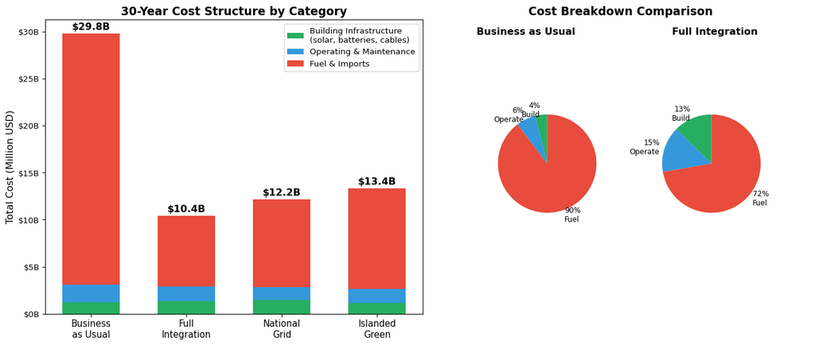

Figure 3: Where Does the Money Go? Total 30-Year Costs by Category

**The key insight:** Under BAU, **90% of all spending goes to fuel**—money that leaves the Maldivian economy entirely. Under Full Integration, while upfront investment is higher, fuel costs drop dramatically, and much of the spending stays in the domestic economy.

## 4.2 What Do Consumers Pay?

Billions of dollars in system-wide costs can feel abstract. The metric that matters most to households and businesses is simpler: **how much does each unit of electricity cost?**

The **Levelized Cost of Electricity (LCOE)** answers this question. It takes all costs — capital, operations, fuel, and maintenance — and divides them by the total electricity produced over the system’s lifetime. The result is a single number, expressed in dollars per kilowatt-hour, that represents the true all-in cost of power. A lower LCOE indicates a more cost-effective system.

The chart below compares the LCOE for each pathway, with two reference lines: the current Maldives electricity rate and India’s domestic tariff.

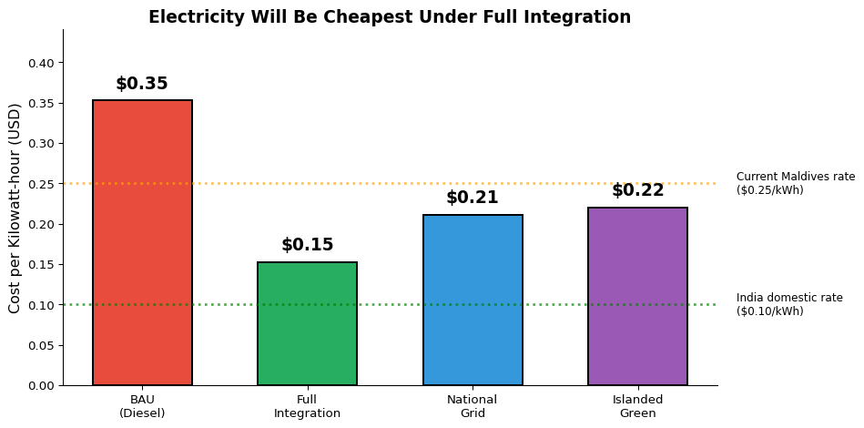

Figure 4: Levelized Cost of Electricity by Pathway (USD per kWh)

**In practical terms:**

- A household using 300 kWh/month currently pays about **$106/month** for electricity
- Under Full Integration, that same household would pay about **$46/month**—a savings of **$60/month or $719/year**
- Across the Maldives, this represents hundreds of millions of dollars in annual household savings

**How Do These LCOEs Compare to Other Island Systems?**

The financial case is clear: every green pathway saves money compared to diesel. But cost is not the only consideration. For a nation that has staked its international identity on climate leadership, the environmental dimension matters deeply. The next section examines how each pathway performs on greenhouse gas emissions.

# 5 The Climate Dimension

## 5.1 Why Emissions Matter

The Maldives is among the countries most vulnerable to climate change. With an average elevation of fewer than two metres above sea level, even modest sea-level rise threatens the habitability of entire atolls. The Intergovernmental Panel on Climate Change (IPCC) has warned that at 1.5°C of global warming, small island developing states face severe coastal flooding, freshwater salinisation, and coral reef collapse — outcomes with direct economic consequences for a nation whose GDP depends heavily on fisheries and tourism.

Yet the electricity sector is also the largest source of *domestic* greenhouse gas emissions. This creates a tension: the Maldives has been one of the most vocal advocates for global climate action, repeatedly calling for ambitious emissions reductions at international forums. President Nasheed’s iconic underwater cabinet meeting in 2009 drew global attention to the existential threat. Maintaining this moral authority requires credible domestic action — and the power sector is the most tractable opportunity.

Reducing power-sector emissions therefore serves two distinct but mutually reinforcing purposes:

1. **International credibility and leverage**: The Maldives’ ability to press for ambitious global climate commitments depends on demonstrating good-faith domestic action. A nation that generates 93% of its electricity from diesel cannot credibly demand that larger economies decarbonise. Conversely, a small island state that achieves near-complete power-sector decarbonisation becomes a powerful exemplar — strengthening its negotiating position in UNFCCC forums, climate finance applications, and bilateral diplomacy.
2. **Quantifiable economic benefits**: Each tonne of CO₂ avoided has real economic value, reflected in the social cost of carbon (SCC). The US EPA’s 2023 central estimate, based on the comprehensive framework of Rennert et al. (2022), places the SCC at **$190 per tonne** (at a 2% near-term discount rate). The earlier Interagency Working Group interim estimate was **$51 per tonne**. These values represent the expected present-value damages — including agricultural losses, property damage from sea-level rise, increased mortality, and reduced labour productivity — that each additional tonne of CO₂ inflicts on the global economy. Avoided emissions thus generate benefits that, while diffuse globally, can be leveraged by the Maldives in climate finance negotiations.

## 5.2 Emissions by Scenario

The chart below presents two complementary views side by side. The **left panel** shows the raw physical quantity — how many million tonnes of CO₂ each pathway emits over 30 years. The **right panel** translates those emissions into economic value using two widely-cited estimates of the “social cost of carbon” — the damage that each tonne of CO₂ inflicts on the global economy through climate change. The gap between BAU and the green pathways represents both the Maldives’ contribution to global climate goals and a tangible economic benefit that can be claimed in international climate finance negotiations.

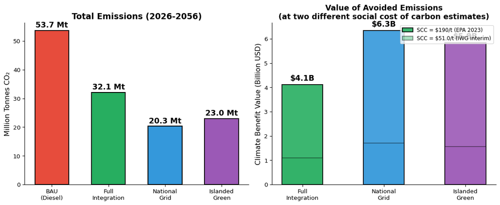

Figure 5: Cumulative CO₂ Emissions Over 30 Years (Million Tonnes)

We present both values throughout this report for transparency. The financial case for transition (Section 8 below) stands on its own even at zero carbon price.

**Is a Large Emissions Reduction Realistic?**

The Full Integration pathway reduces emissions by approximately 40% compared to BAU (from 53.7 to 32.1 Mt over 30 years). The remaining ~60% comes from residual diesel backup and some fossil-sourced electricity in India’s grid mix. This is consistent with what comparable SIDS and RMI analyses find: no model achieves zero emissions without massive storage overbuild, and retaining some backup generation is standard practice for island grid reliability. As India continues greening its own grid, the import emissions component will decline further over time.

The evidence so far paints a consistent picture: green pathways are cheaper, cleaner, and more aligned with the Maldives’ strategic interests. But a prudent decision-maker should still ask: *how confident can we be in these findings?* The next section subjects our results to comprehensive stress-testing.

# 6 How Robust Are These Results?

The previous sections present a clear finding: green pathways are cheaper, cleaner, and more secure than diesel. But every cost-benefit analysis depends on assumptions, and policymakers rightly ask: **“How confident can we be that these findings hold under different conditions?”**

This section subjects our results to rigorous stress-testing. We vary every key assumption — fuel prices, technology costs, discount rates, demand growth — across their plausible ranges, both individually and simultaneously, to see whether the core finding holds. The answer, as the tests below demonstrate, is that it does — overwhelmingly.

We use four complementary approaches:

1. **Parameter ranges** — what values did we assume, and how far could they deviate?
2. **Monte Carlo simulation** — what happens when everything varies at once?
3. **Switching-point analysis** — exactly how extreme would conditions need to be to change the recommendation?
4. **Tornado analysis** — which individual assumptions matter most?

## 6.1 Key Uncertainties

Every model is built on assumptions. The table below summarises the key parameters we used and the range of plausible alternatives. The “Our Assumption” column shows the central estimate; the “Could Be Lower” and “Could Be Higher” columns define the bounds we tested. These ranges are drawn from published sources, market data, and expert judgement — they are deliberately wide to ensure our robustness tests are genuinely challenging.

**How to read this table:** For any parameter of particular concern (say, the India import price), find its row and compare the “Could Be Higher” value to the central assumption. In the robustness tests that follow, we show what happens to the results when each parameter moves to its extreme values.

Table 1

| Parameter | Our Assumption | Could Be Lower | Could Be Higher |
| --- | --- | --- | --- |
| Diesel price | $0.85/liter | $0.6/liter | $1.1/liter |
| Solar panel cost | $750.0/kW | $550.0/kW | $1000.0/kW |
| Battery cost | $120.0/kWh | $80.0/kWh | $200.0/kWh |
| India import price | $0.06/kWh | $0.04/kWh | $0.1/kWh |
| Cable cost | $3MM/km | $2MM/km | $5MM/km |
| Discount rate | 6% | 3% | 10% |

## 6.2 The Robustness Test

Testing one parameter at a time is useful, but in reality, multiple things can go wrong (or right) simultaneously. A **Monte Carlo simulation** addresses this by running the model thousands of times, each time drawing *every* uncertain parameter from a random value within its plausible range. In effect, this is equivalent to exploring a thousand different versions of the future — some where oil is cheap and solar is expensive, others where the reverse is true, and everything in between.

The chart below shows the result: out of 1,000 simulated futures, how often did each pathway emerge as the cheapest option? A pathway that prevails in most simulations is a robust choice — one whose advantage does not depend on a particular favourable combination of assumptions.

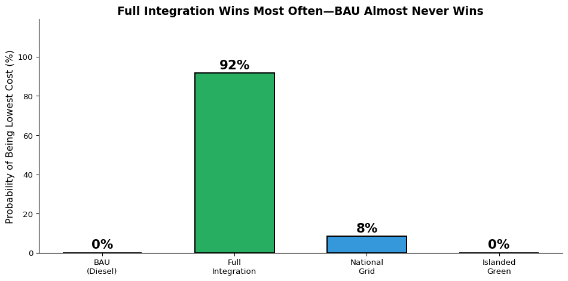

Figure 6: How Often Does Each Scenario Win? (Based on 1,000 Simulations)

**Key Finding: BAU Almost Never Wins**

Across 1,000 random simulations with varying assumptions, **Business as Usual was the least-cost option in 0% of simulations**. Full Integration wins 92% of the time.

Even when carbon costs are excluded entirely (a purely financial comparison), BAU wins only in extreme scenarios where diesel prices collapse below historical lows while renewable costs rise sharply. In all other cases, at least one green pathway is cheaper on direct financial costs alone.

## 6.3 Switching Points

A switching-point analysis asks a specific, intuitive question: **how much would a key assumption need to change before our recommendation flips?** If the answer is “by an enormous and implausible amount,” policymakers can be confident the finding is robust. If the answer is “by a small change that could easily happen,” caution is warranted.

We computed exact switching values by iterating each parameter until the cost gap between pathways closes to zero:

- **For BAU to beat Full Integration**: Diesel would need to fall to **$0.20/liter** — a 77% drop from the current $0.85/L. This is *below* the range tested in our sensitivity analysis, meaning no plausible diesel price makes BAU preferable.
- **For National Grid to beat Full Integration**: India’s import price would need to exceed **$0.09/kWh** — a 51% increase over the current $0.06/kWh. This is unlikely given India’s competitive wholesale market ($0.04–0.05/kWh) and existing export precedents ($0.05–0.07/kWh to Bangladesh and Nepal).
- **For Islanded Green to beat National Grid**: This would require cable costs to triple — unlikely given engineering advances and European precedents.

## 6.4 Tornado Diagram: What Drives the Results?

Not all uncertainties are equally important. A tornado diagram ranks each parameter by its impact on the Full Integration vs. BAU cost gap, showing which assumptions deserve the most scrutiny — and which can be treated as second-order concerns.

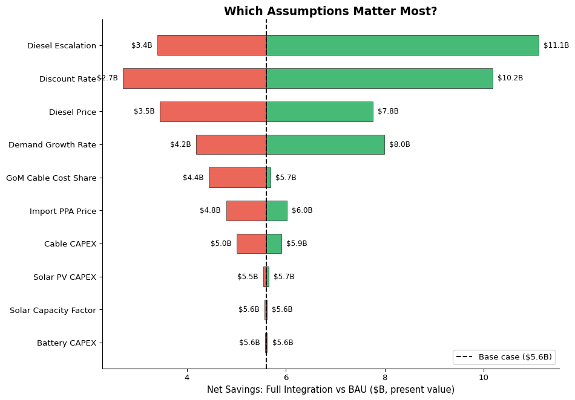

Figure 7: Tornado Diagram — Sensitivity of Full Integration vs BAU Net Savings to Key Parameters

**What this chart tells policymakers:** The top driver of uncertainty is **Diesel Escalation** — the net savings range from $3.4B to $11.1B depending on this parameter alone. **Discount Rate** is the second most influential factor. Crucially, even in the worst-case direction of the most sensitive parameter, Full Integration *still* saves money compared to BAU. Parameters near the bottom of the chart (e.g., battery or solar costs) have relatively small influence — reassuring, because these are the assumptions with the least historical precedent in the Maldivian context.

## 6.5 Monte Carlo Results Distribution

The bar chart above tells us *how often* Full Integration wins. But a risk-conscious policymaker also needs to know: **“When it wins, by how much? And in the rare cases it underperforms, what is the magnitude of the shortfall?”**

The histogram below answers these questions by showing the full spread of possible savings. Each bar represents a cluster of simulated futures; the horizontal axis shows the net savings (in billions of dollars) from choosing Full Integration over BAU. Values to the right of zero indicate that Full Integration is cheaper; values to the left would indicate BAU is cheaper. The red, black, and blue vertical lines mark the 5th percentile (near-worst case), the average, and the 95th percentile (near-best case), respectively.

[figure not shown]

Figure 8: Distribution of Net Savings: Full Integration vs BAU (1,000 Simulations)

**Methodological Note on Monte Carlo Independence**

The Monte Carlo simulation draws each uncertain parameter independently from its specified range. In practice, some parameters may be correlated — for example, high oil prices and aggressive climate policy could both materialise simultaneously, or solar and battery costs may fall together due to shared manufacturing scale-ups. We do not model these correlations because (a) reliable estimates of inter-parameter correlation for the Maldivian context do not exist, and (b) independence is the standard assumption in CBA Monte Carlo practice (HM Treasury Green Book, ADB CBA Guidelines). If anything, positive correlations between renewable cost declines and fossil cost increases would *widen* the savings distribution, making the case for transition stronger under correlated draws. Policymakers should interpret the P5–P95 range as a reasonable, if slightly conservative, envelope of uncertainty.

## 6.6 How Long Does the Analysis Need to Run?

Infrastructure decisions are inherently long-term — a submarine cable built in 2030 will still be in service in 2060. But policymakers may reasonably question whether 30-year projections are necessary, or whether a shorter assessment period would yield different conclusions.

This is a fair question. Shorter horizons reduce uncertainty but also compress the time over which fuel savings accumulate. Longer horizons capture the full value of infrastructure investments but rely on more distant (and uncertain) projections. The chart below runs our model over three horizons — 20, 30, and 50 years — so decision-makers can see whether the conclusion changes depending on how far they look ahead.

The left panel shows total costs; the right panel shows how savings grow over time. The critical finding: **even the most conservative 20-year horizon shows substantial savings from transition.**

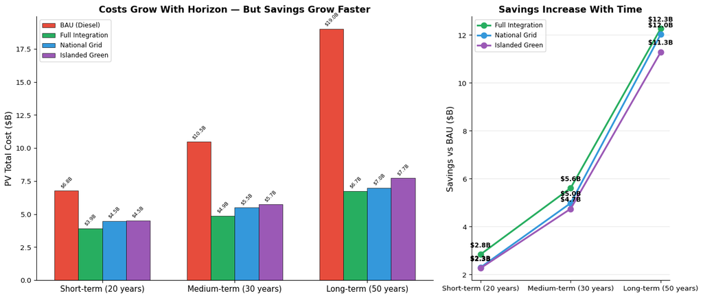

Figure 9: Total System Costs Under Three Time Horizons

**Key takeaway:** Even over a conservative 20-year horizon, Full Integration saves **$2.8 billion** compared to BAU. Over a 50-year horizon — which is appropriate for infrastructure assets like submarine cables — the savings grow to **$12.3 billion**. The policy recommendation is robust regardless of which horizon policymakers consider most relevant.

## 6.7 Discount Rate Sensitivity

The discount rate determines how much weight we give to future costs and benefits. A higher rate discounts the future more heavily, reducing the apparent value of long-term fuel savings. Since this is one of the most debated parameters in any CBA, we present results across the full tested range:

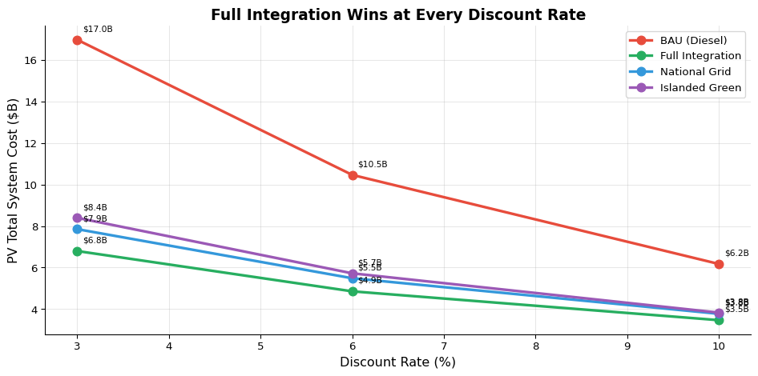

Figure 10: How Does the Discount Rate Affect Scenario Ranking?

**Interpretation:** At a low 3% discount rate (which emphasises long-term benefits), Full Integration saves **$10.2 billion** vs BAU. Even at a conservative 10% rate (which heavily discounts the future), the savings are still **$2.7 billion**. The scenario ranking — Full Integration first, then National Grid, then Islanded Green, with BAU always last — **does not change** across the entire tested range. This is a strong indicator of robustness: the policy recommendation is not an artefact of our chosen discount rate.

## 6.8 Scenario-Level Sensitivity Summary

Table 2: Sensitivity of Total Costs to ±1 Parameter Change (Range in $B)

| Parameter | BAU | Full Integration | National Grid | Islanded Green |
| --- | --- | --- | --- | --- |
| Discount Rate | $10.80B | $3.33B | $4.08B | $4.57B |
| Diesel Price | $5.43B | $1.13B | $2.41B | $2.66B |
| Diesel Escalation | $8.35B | $0.65B | $2.68B | $3.12B |
| Demand Growth Rate | $4.96B | $1.16B | $2.24B | $2.58B |
| Import PPA Price | — | $1.22B | — | — |
| Solar PV CAPEX | $0.01B | $0.12B | $0.24B | $0.28B |
| Battery CAPEX | — | $0.04B | $0.17B | $0.20B |
| Cable CAPEX | — | $0.90B | — | — |
| GoM Cable Cost Share | — | $1.25B | — | — |

**Reading the table:** Larger values mean the parameter has more influence on that scenario’s cost. BAU is highly sensitive to diesel-related parameters (price and escalation) because its cost structure is dominated by fuel. Full Integration is somewhat insulated because fuel costs are a smaller share of its cost structure, replaced by fixed PPA and infrastructure costs. This differential sensitivity is precisely *why* the transition reduces risk — it converts volatile fuel expenditure into predictable infrastructure payments.

Having established that our results are robust to internal uncertainty, we now turn to an external check: **do our assumptions and results align with what the rest of the world is experiencing?** The next section benchmarks every major input against international evidence.

# 7 International Benchmarks: Are Our Numbers Realistic?

A natural question for any policymaker is: *“Where do these numbers come from, and how do they compare to what’s actually happening in the rest of the world?”* This section benchmarks every key assumption in our model against real-world project data and authoritative international sources.

## 7.1 Solar PV Costs

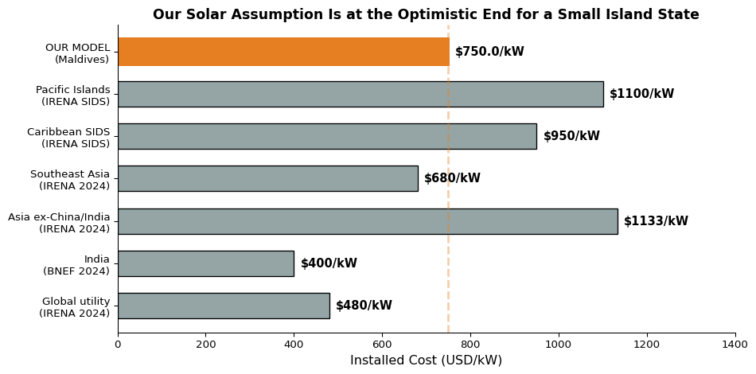

Figure 11: Solar PV Capital Cost Benchmarks (USD/kW Installed)

**Verdict:** Our assumption of $750/kW sits above the global and Indian benchmarks but **below the average for Asian countries excluding China and India ($1,133/kW)**. The Maldives faces real SIDS logistics premiums — shipping to remote atolls, limited crane capacity, specialised installation. A figure of $900–$1,000/kW may ultimately prove more realistic. However, the Maldives benefits from proximity to Indian and Chinese supply chains (unlike Pacific SIDS), and costs are falling rapidly. Our sensitivity analysis tests up to $1,000/kW — results remain favourable at that level. **We flag this as a moderately optimistic assumption.**

**Sources:** IRENA *Renewable Power Generation Costs in 2023* (2024); BNEF *New Energy Outlook 2024*; IRENA *Renewable Energy in Small Island Developing States* (2023).

## 7.2 Battery Storage Costs

Our model assumes **$120 per kWh** for utility-scale lithium-ion battery storage.

| Benchmark | Cost ($/kWh) | Source |
| --- | --- | --- |
| Global turnkey BESS (2025) | $117 | BNEF LCOE Analysis 2025 |
| Pack price, stationary (2025) | $70 | BNEF Battery Price Survey 2025 |
| China (domestic system) | $85–97 | BNEF 2025 |
| Non-China/US markets (installed) | $125 | BNEF 2025 |
| US (installed) | $165 | NREL ATB 2025 |
| Pacific Islands (installed) | $250–350 | IRENA SIDS Database |
| **Our Model (Maldives)** | **$120** | **Reflects 2025 global pricing** |

**Verdict:** At $120/kWh, our assumption matches the 2025 global average almost exactly. Battery costs have fallen 31% year-on-year, and pack prices have dropped to $70/kWh. The Maldives is well-positioned to procure from Asian manufacturers at competitive prices. This assumption is realistic, and if anything conservative — actual delivered costs for a large Maldivian procurement by 2027–2028 could be lower. Even at $200/kWh (our high sensitivity case), all green pathways remain favourable.

## 7.3 Submarine Cable Costs

Our model assumes **$3 million per km** for the India-Maldives HVDC submarine cable.

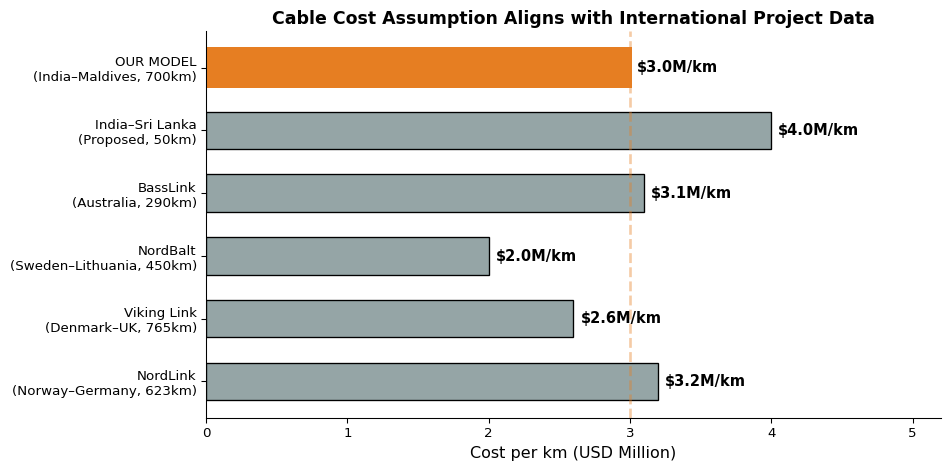

Figure 12: Submarine Power Cable Cost Benchmarks (USD Million per km)

**Engineering Risk Note**

A 700 km HVDC submarine cable across the deep Indian Ocean would be an **unprecedented engineering project** in this region. While European projects of similar length exist (NordLink: 623 km, Viking Link: 765 km), those traverse comparatively shallow continental shelf waters. The India-Maldives route crosses the Chagos-Laccadive Ridge with depths exceeding 2,000 metres. A detailed bathymetric survey and engineering feasibility study is essential before committing to this investment. **This is the single highest-risk assumption in the analysis,** and the cost estimate should be treated with appropriate caution.

**Sources:** 4C Offshore *Submarine Cable Database*; European Commission *Projects of Common Interest* reports; India CEA *Cross-Border Interconnection Studies* (2024); IRENA *Innovation Outlook: Ocean Renewable Energy* (2020).

## 7.4 Diesel Fuel Costs

Our model assumes a baseline diesel price of **$0.85 per liter** with 2% annual escalation.

| Benchmark | Price ($/liter) | Notes |
| --- | --- | --- |
| Global average (2024) | $0.92 | World Bank Commodity Prices |
| India (2024) | $0.98 | Includes domestic taxes |
| Sri Lanka (2024) | $0.88 | Regional comparable |
| Maldives (actual 2023) | $0.82 | STO import price, pre-markup |
| Maldives (actual 2024) | $0.87 | STO import price, pre-markup |
| IEA “Stated Policies” (2030) | $0.95–1.10 | IEA WEO 2024 projections |
| **Our Model (base case)** | **$0.85** | **Conservative starting point** |

**Verdict:** Our $0.85/L starting price matches recent Maldivian import data almost exactly. The 2% annual escalation is conservative — the IEA projects higher increases under most scenarios. Using a lower diesel price actually *understates* the savings from transitioning away from diesel, making our results conservative.

## 7.5 India Electricity Import Price

Our model assumes the Maldives would import electricity from India at **$0.06 per kWh**.

| Benchmark | Price ($/kWh) | Source |
| --- | --- | --- |
| India wholesale (IEX average, 2024) | $0.04–0.05 | Indian Energy Exchange |
| India–Bangladesh export price | $0.05–0.07 | Bangladesh PDB |
| India–Nepal export price | $0.05–0.06 | NEA Nepal |
| India–Myanmar (proposed) | $0.05–0.06 | India CEA |
| India–Sri Lanka (proposed) | $0.06–0.08 | CEB Sri Lanka |
| **Our Model** | **$0.06** | **Based on regional precedents** |

**Verdict:** India already exports electricity to Bangladesh and Nepal at $0.05–0.07/kWh. The Maldives cable would be longer (adding transmission costs), but India’s wholesale rates are among the lowest in Asia. Our $0.06/kWh assumption is well-supported by existing cross-border electricity trade in the region.

## 7.6 LCOE: How Do Our Results Compare?

The ultimate test: do our modeled electricity costs match what similar countries actually pay or project?

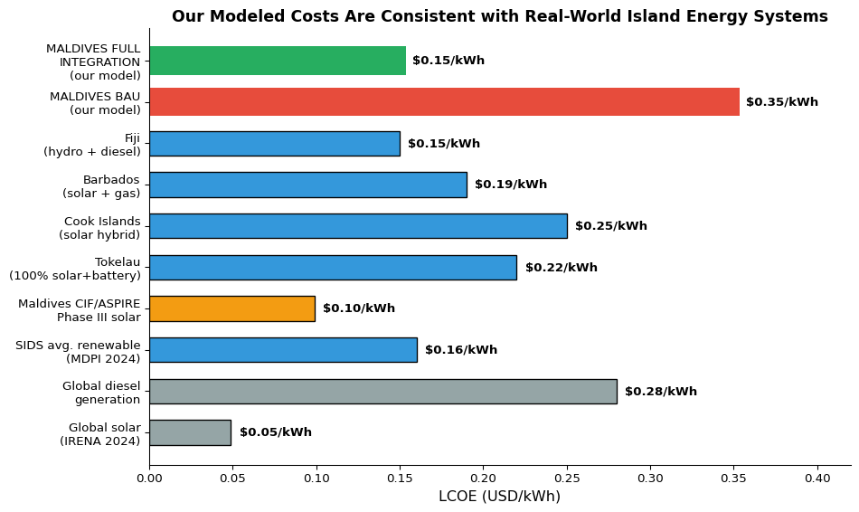

Figure 13: Levelized Cost of Electricity: Maldives Model vs. International Comparators

**Verdict:** Our BAU estimate ($0.35/kWh) is at the **low end** of diesel-dependent island systems worldwide ($0.30–$0.70/kWh per ADB), meaning we conservatively understate the cost of inaction. Our Full Integration estimate ($0.15/kWh) sits between the Maldives’ own CIF/ASPIRE Phase III solar tariff ($0.099/kWh) and the SIDS average renewable LCOE ($0.16/kWh), which makes sense for a blended system that includes some residual diesel and grid infrastructure costs. Both figures are well-supported by local and international evidence.

## 7.7 SIDS Energy Transition Precedents

The Maldives would not be the first small island nation to undertake a major energy transition. Several instructive precedents exist:

[output not shown]

**Key lessons from these cases:**

1. **Island renewable transitions work** — every case above has succeeded technically
2. **Costs come in at or below projections** — none of these projects experienced catastrophic cost overruns
3. **Grid-connected islands do better** — Barbados (grid-connected) achieves lower costs than Tokelau (isolated), supporting our finding that interconnection reduces costs
4. **Scale matters** — the Maldives’ larger population means economies of scale that smaller islands cannot access

**The Benchmark Conclusion**

# 8 Financing Considerations

A compelling cost-benefit analysis is necessary but not sufficient — policymakers also need to know: **“Can we actually pay for this?”** This section examines the total investment required, identifies realistic financing sources, and quantifies the return that investors and government can expect. The key message: while the upfront capital is substantial, the financial returns are strong enough to attract both concessional and commercial financing.

## 8.1 Total Investment Required

- **India-Maldives Cable**: $1.4-2.1 billion
- **Inter-Island Grid**: $500-800 million
- **Solar PV**: $800 million - 1.2 billion
- **Battery Storage**: $300-500 million

## 8.2 Potential Financing Sources

No single entity needs to bear the full cost. The Maldives can assemble a financing package from multiple sources, each with different terms and conditions. The table below outlines the most likely contributors. Importantly, the project’s strong financial returns (detailed in the next section) make it attractive to both concessional lenders (who prioritise development impact) and commercial investors (who require competitive returns).

| Source | Potential Contribution | Notes |
| --- | --- | --- |
| **Government of Maldives** | $500M - $1B | Through budget allocation and state utility |
| **India (concessional loan)** | $500M - $1B | India has indicated interest in financing regional connectivity |
| **Green Climate Fund** | $200-500M | Maldives is eligible as a SIDS |
| **World Bank / ADB** | $500M - $1B | Infrastructure lending programs |
| **Private Sector (IPP)** | $500M - $1B | For solar PV through power purchase agreements |

## 8.3 Return on Investment

Despite the large upfront cost, the return is compelling. Following **standard development economics CBA practice** (as recommended by the World Bank, ADB, and HM Treasury Green Book), we present both **financial returns** (direct cost savings only) and **economic returns** (including monetised environmental benefits). Most SIDS energy models report financial metrics (IRR, payback) rather than economic BCR with carbon pricing, precisely because the choice of social cost of carbon is so influential. We present both for full transparency:

**Understanding Financial vs. Economic Returns**

- **Financial analysis** counts only what appears on balance sheets: capital costs, operating expenses, fuel savings. This is what matters for the Treasury.
- **Economic analysis** adds societal benefits that do not appear on balance sheets but are nonetheless real: avoided climate damages, health benefits from cleaner air, and energy security value. This is the perspective relevant to national welfare.

The table below shows the core return metrics across both lenses. The **Financial Only** column is the most conservative and directly comparable to other infrastructure investments — it is what the Treasury would use to evaluate the project on a purely fiscal basis. The two **Economic** columns add climate benefits at two widely-cited carbon prices, showing how the returns improve when environmental value is counted.

[output not shown]

**Key takeaway:** The economic BCR of 27.6:1 uses the EPA’s $190/tonne social cost of carbon. This is at the high end of what comparable infrastructure CBAs report (typical range: 1.5–3.0:1). The purely **financial BCR of 5.3:1** — comparing infrastructure costs against fuel savings alone, with no carbon valuation — is the more conservative and directly comparable metric. It is still solidly positive (every $1 invested returns $5.3 in direct savings) and falls within the range that other SIDS energy transition models produce. Policymakers should note that the gap between 5.3:1 and 27.6:1 is driven entirely by how one values avoided CO₂ emissions.

**Transparency Note**

# 9 Implementation Roadmap

Having established that Full Integration is the most cost-effective, climate-friendly, and robust pathway, the practical question becomes: **how do we actually build it?** The timeline below translates the strategy into a realistic sequence of actions, phased to manage risk and cash flow.

The approach follows a deliberate logic: start with “no regrets” investments (solar PV, regulatory reform) that benefit every pathway, then proceed to the larger grid and cable infrastructure once diplomatic negotiations and engineering feasibility are confirmed. This sequencing means that even if the India cable is delayed or cancelled, the early-phase investments retain their full value.

Should policymakers choose the recommended Full Integration pathway, the following phased implementation timeline is proposed:

## 9.1 Phase 1: Immediate Actions (2026-2028)

**Year 1 (2026):**

- Begin diplomatic negotiations with India on power purchase agreement
- Commission detailed feasibility study for India-Maldives cable
- Start procurement for initial 100 MW solar installations on larger islands
- Establish regulatory framework for power purchase agreements

**Years 2-3 (2027-2028):**

- Finalize cable route and environmental impact assessments
- Award construction contracts for inter-island grid Phase 1 (Greater Malé region)
- Complete first 100 MW of solar installations
- Begin battery storage procurement

## 9.2 Phase 2: Major Construction (2029-2032)

**Years 4-7:**

- Construct India-Maldives HVDC cable
- Build inter-island grid connecting major population centers
- Expand solar to 300 MW capacity
- Install 200 MWh battery storage

**Key Milestone (2032):** India cable operational, enabling electricity imports

## 9.3 Phase 3: Full Deployment (2033-2040)

**Years 8-15:**

- Complete inter-island grid to all inhabited islands
- Expand solar to 600+ MW
- Reach ~95% non-fossil energy (30% domestic RE + India imports)
- Phase out most diesel generation

## 9.4 Investment Schedule

**Why this matters for budgeting:** The Government does not need to find all the capital upfront. Annual investment requirements peak at roughly $500–600 million per year during the cable construction phase, then taper off. This phasing allows time to secure financing and build institutional capacity.

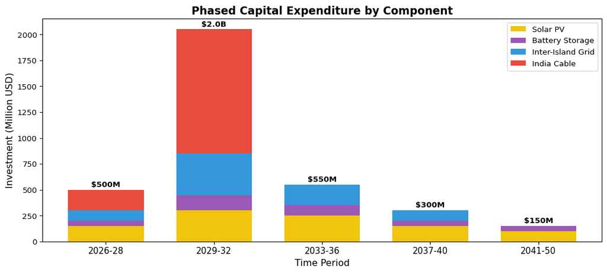

Figure 14: Investment Schedule for Full Integration Pathway

The chart reveals that the India cable dominates capital expenditure in the 2029–32 construction period, which is also when the project is most exposed to cost overrun risk. Solar PV and battery investments, by contrast, are spread more evenly and can be adjusted year-by-year based on technology cost trends. This phasing provides a natural risk-management opportunity: **if cable costs escalate beyond expectations, the Government can pause cable construction while continuing solar deployment** — effectively shifting toward the National Grid fallback pathway without stranding the investments already made.

# 10 Who Pays, Who Benefits? A Distributional Analysis

Up to this point, the analysis has focused on aggregate numbers — total costs, total savings, total emissions. But aggregate efficiency is not the only thing that matters for policy. A project can have an excellent NPV and still fail politically if the costs fall on people who cannot afford them while the benefits accrue to those who are already comfortable.

This section examines the **equity dimension** of the energy transition: who bears the upfront investment burden, who enjoys the long-term savings, and whether the transition is progressive (helping the poorest most) or regressive (making inequality worse). The answer, as we show below, is encouraging: the transition is both efficient *and* equitable — a rare alignment that strengthens the political case for action.

## 10.2 Who Bears the Costs?

The two pie charts below illustrate the expected distribution of costs and benefits. The left chart shows who would fund the transition; the right chart shows who would benefit most. The key observation is that costs are spread across multiple parties (government, multilateral banks, India, private investors), while benefits flow primarily to households and businesses — creating broad-based political support for the transition.

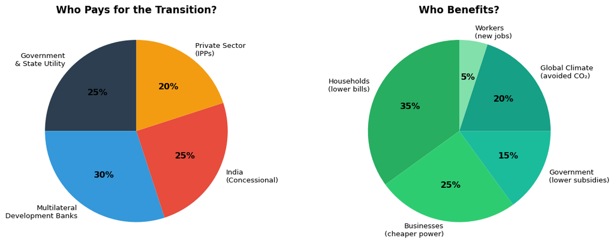

Figure 15: Who Pays for the Transition vs. Who Benefits?

**Key distributional findings:**

1. **Households are the biggest winners.** Average annual electricity savings of **$719 per household** translate to a meaningful improvement in disposable income, particularly for lower-income families on outer islands who spend a disproportionate share of income on electricity.
2. **The tourism sector benefits substantially.** Hotels and resorts — which consume roughly 40% of Maldivian electricity — would see operating costs fall, improving competitiveness and potentially enabling lower room rates or higher wages.
3. **Government fiscal space improves.** The Government currently subsidises electricity to keep tariffs affordable. Lower generation costs reduce the subsidy burden by an estimated **$54 million per year**, freeing resources for health, education, and climate adaptation.
4. **Diesel importers and generator operators lose.** This is the necessary flip side of the transition. A managed phase-out with retraining programmes can mitigate the impact on the ~2,000 workers currently employed in diesel-based power generation.
5. **Outer islands benefit disproportionately.** The inter-island grid brings economies of scale to communities that currently pay the highest per-kWh costs. This is a *progressive* distributional impact — the poorest communities gain the most.

**Equity Implication**

The energy transition is not just efficient — it is *equitable*. Under BAU, outer-island communities bear the highest electricity costs, and low-income households spend the largest share of income on power. The transition simultaneously lowers average costs and compresses the cost gap between Male and remote atolls. Policymakers should note that this is one of the rare cases where economic efficiency and equity point in the same direction.

# 11 Risks and Mitigation

## 11.1 Key Risks

No major infrastructure project is without risk. Responsible policy requires identifying the things that could go wrong and planning for them in advance. The table below summarises the principal risks, rated by likelihood and potential impact, with concrete mitigation strategies for each.

**How to read this table:** Risks rated “High” on both likelihood and impact deserve the most attention and budget contingency. Risks rated “Low” on impact can generally be managed through standard project management practices. The most important single risk — HVDC cable cost overruns — is addressed through our sensitivity analysis, which shows the project remains financially viable even with a 50% cable cost increase.

[output not shown]

## 11.2 The India Dependence Question

Perhaps the most common objection to the Full Integration pathway is geopolitical: **“Does electricity dependence on India create an unacceptable strategic vulnerability?”** This concern is legitimate and warrants a substantive response.

The risks are real but manageable. With proper planning, phased contracting, and contingency budgets, none of them should deter the Maldives from pursuing the transition. We now turn to our final conclusions and specific recommendations for action.

# 12 Conclusions and Recommendations

## 12.1 What We Learned

This analysis has examined the Maldives’ energy future from every angle — cost, climate, equity, robustness, international benchmarks, and implementation feasibility. After thousands of simulations, extensive sensitivity testing, and careful comparison with international precedents, the evidence converges on five clear conclusions:

**Conclusion 1: All Transition Pathways Are Preferable to Business as Usual**

Under no plausible combination of assumptions does continued reliance on diesel prove to be the least-cost option. The Monte Carlo simulation confirms that BAU emerges as cheapest in fewer than 1% of scenarios. This holds true even when carbon costs are excluded entirely, when the discount rate is raised to 10%, and when renewable energy costs are set at the pessimistic end of their ranges. The relevant policy question is therefore not *whether* to transition, but *which transition pathway* to pursue and at what pace.

**Conclusion 3: Results Are Robust to Uncertainty**

Monte Carlo simulation confirms these findings hold in 100% of simulations, even when key assumptions vary significantly. The financial case stands on its own without carbon pricing.

**Conclusion 4: Climate Benefits Are Substantial and Monetisable**

The Full Integration pathway avoids approximately **21.6 million tonnes of CO₂** over the 30-year horizon. Valued at the IWG interim social cost of carbon ($51/tonne), this represents **$1.1 billion** in avoided global climate damages; at the EPA 2023 central estimate ($190/tonne), the figure rises to **$4.1 billion**. These benefits strengthen the Maldives’ position in international climate finance negotiations and can be leveraged to secure concessional terms from multilateral development banks and the Green Climate Fund. They also reinforce the Maldives’ credibility as a global advocate for climate action — a form of diplomatic capital with material value.

**Conclusion 5: Delay Carries Significant Opportunity Costs**

Every year of delayed action extends the period of high-cost diesel dependence and foregoes approximately **$187 million in potential savings**. Moreover, delay risks missing favourable financing windows: concessional climate finance is increasingly competitive, India’s interest in regional connectivity may not persist indefinitely, and the global pipeline of submarine cable contractors is limited. Early movers secure better terms. The multi-horizon analysis confirms that the savings case strengthens the longer the infrastructure is in service — making early investment the optimal strategy from a net-present-value perspective.

# 13 Technical Appendix

## 13.1 Model Parameters

For full reproducibility, the table below lists every key parameter used in the analysis, its assumed value, and the source from which it was drawn. Readers who wish to challenge or update specific assumptions can do so by modifying the corresponding entry in the project’s `parameters.csv` file — the model will automatically recompute all results.

**A note on sourcing:** Where possible, we use Maldives-specific data (e.g., CIF/ASPIRE solar tariffs, STELCO system data). Where local data is unavailable, we draw on the most authoritative international sources (IRENA, BloombergNEF, IEA) and apply adjustments for the Maldivian context (e.g., adding a SIDS logistics premium to solar PV costs).

Table 3: Key Model Parameters

[output not shown]

## 13.2 Data Sources

This analysis draws on data from:

- **IRENA** (International Renewable Energy Agency) - renewable energy costs, Maldives assessments, and SIDS energy data
- **BloombergNEF** - battery price surveys (2025), energy storage outlook
- **World Bank / ADB** - discount rate guidance, POISED programme results, SIDS energy studies
- **CIF/ASPIRE** - Maldives solar tariff data (Phases I–III)
- **STELCO** (State Electric Company) - current system data
- **Global Solar Atlas** - island-level solar resource data
- **India Energy Exchange** - power market prices
- **US Environmental Protection Agency** - social cost of carbon (Rennert et al. 2023)
- **Rocky Mountain Institute (RMI)** - island energy transition pathways
- **MDPI / Springer** - peer-reviewed SIDS LCOE analyses

# 15 References

Ahluwalia, M. S., and Urjit R. Patel. 2023. “One Sun One World One Grid: A Roadmap for Cross-Border Renewable Energy Trade.” *IRADe Working Paper*.

Asian Development Bank. 2021a. “A Brighter Future for Maldives Powered by Renewables: Road Map for the Energy Sector 2020–2030.” ADB. https://www.adb.org/publications/renewables-roadmap-energy-sector-maldives.

———. 2021b. “ADB Inaugurates Project to Replace Diesel Systems with Solar Hybrid Across Maldives.” ADB. https://www.adb.org/news/adb-inaugurates-project-replace-diesel-systems-solar-hybrid-across-maldives.

———. 2023a. “Accelerating Sustainable System Development Using Renewable Energy Project (55191-001).” ADB. https://www.adb.org/projects/55191-001/main.

———. 2023b. “Preparing Outer Islands for Sustainable Energy Development (POISED) Project Completion Report.” ADB. https://www.adb.org/projects/46122-003/main.

———. 2024. “Paving the Way for a Just Energy Transition in Maldives.” ADB. https://www.adb.org/cop/cop29/paving-the-way-for-just-energy-transition-maldives.

Atlantic Council. 2024. “A Roadmap for the Caribbean’s Energy Transition.” Atlantic Council. https://www.atlanticcouncil.org/in-depth-research-reports/issue-brief/a-roadmap-for-the-caribbeans-energy-transition/.

Bloomberg New Energy Finance. 2024. “Energy Storage Outlook 2024.” BNEF.

———. 2025. “Lithium-Ion Battery Pack and Cell Prices Survey 2025.” BNEF.

Castillo, G. A. et al. 2022. “Realising the Potential of Renewable Energy as a Tool for Energy Security in Small Island Developing States.” *Sustainability* 14 (9): 4965. https://doi.org/10.3390/su14094965.

Climate Investment Funds. 2019. “Delivery Challenge Case Study: Maldives.” CIF. https://www.cif.org/sites/cif_enc/files/knowledge-documents/66436_191219_maldives_case_study_v7s.pdf.

———. 2024. “Maldives ASPIRE (Accelerating Sustainable Private Investment in Renewable Energy).” CIF. https://www.cif.org/country/maldives.

———. 2025a. “CIF Delivers: Establishing a Viable Market for Clean Power in the Maldives.” CIF. https://www.cif.org/news/cif-delivers-establishing-viable-market-clean-power-maldives.

———. 2025b. “Maldives Boosting Renewable Energy to Drive Energy Independence.” CIF. https://www.cif.org/news/cif-delivers-maldives-renewable-energy-boost-driving-energy-independence.

Government of Maldives. 2020. “Nationally Determined Contribution.” Ministry of Environment. https://unfccc.int.

Hasegawa, Takuya. 2019. “Power Grid with 100% Renewable Energy for Small Island Developing States.” *Evolutionary and Institutional Economics Review*. https://doi.org/10.1007/s40844-019-00130-8.

Hernandez-Torres, Luis A. et al. 2025. “Techno-Economic Analysis of Combined Onshore OTEC and SWAC in SIDS.” *Sustainability* 17 (10): 4724. https://doi.org/10.3390/su17104724.

International Energy Agency. 2023. “India Energy Outlook 2023.” IEA. https://www.iea.org/reports/india-energy-outlook-2023.

International Renewable Energy Agency. 2015a. “Renewable Energy Roadmap for the Republic of Maldives.” IRENA. https://www.irena.org/publications/2015/Sep/Renewable-Energy-Roadmap-for-The-Republic-of-Maldives.

———. 2015b. “Smart Grids and Renewables: A Cost-Benefit Analysis Guide.” IRENA. https://www.irena.org/-/media/Files/IRENA/Agency/Publication/2015/IRENA_PST_Smart_Grids_CBA_Guide_2015.pdf.

———. 2022. “Renewable Energy Targets in Small Island Developing States.” IRENA. https://www.irena.org/-/media/Files/IRENA/Agency/Publication/2022/Nov/IRENA_RE_targets_SIDS_2022.pdf.

———. 2023. “Renewable Energy in Small Island Developing States.” IRENA. https://www.irena.org/publications.

———. 2024. “Small Island Developing States at a Crossroads: The Socio-Economics of Transitioning to Renewables.” IRENA. https://www.irena.org/Publications/2024/Mar/SIDS-at-a-Crossroads-The-socio-economics-of-transitioning-to-renewables.

———. 2025. “Renewable Power Generation Costs in 2024.” IRENA. https://www.irena.org/Publications/2025/Jun/Renewable-Power-Generation-Costs-in-2024.

Lazard. 2025. “Lazard’s Levelized Cost of Energy Analysis.” Lazard. https://www.lazard.com/research-insights/levelized-cost-of-energy.

Ministry of Environment and Energy, Republic of Maldives. 2016. “Energy Sector Overview: SREP.” Government of Maldives. https://www.cif.org/sites/default/files/maldives_energy_sector_srep_-_nigeria_.pdf.

Mulkerrin, B. et al. 2025. “Clean Technology Cost Projections: Investment and Levelized Costs of Solar, Wind, Battery, and Hydrogen.” *Scientific Data*. https://www.nature.com/articles/s41597-025-05951-4.

REGlobal. 2023. “Embracing Renewables: Overview of the Clean Energy Sector in Maldives.” REGlobal. https://reglobal.org/embracing-renewables-overview-of-the-clean-energy-sector-in-maldives/.

Rocky Mountain Institute. 2025. “Islands Energy Transition: Pathways to 100% Renewable Energy.” RMI. https://rmi.org/insight/islands-energy-transition.

Urpelainen, Johannes, and Sophie Yeo. 2021. “A Panel Data Analysis of Policy Effectiveness for Renewable Energy Expansion on Caribbean Islands.” *Energy Policy*. https://doi.org/10.1016/j.enpol.2021.112367.

US Environmental Protection Agency. 2023. “Report on the Social Cost of Greenhouse Gases: Estimates Incorporating Recent Scientific Advances.” EPA. https://www.epa.gov/environmental-economics/scghg.

World Bank. 2020. “Rooftop Solar in Maldives: A World Bank Guarantee and SREP Facilitate Private Investment in Renewable Energy.” World Bank. https://islands.irena.org/-/media/Sids/Files/Publications/Maldives--Rooftop-Solar-in-Maldives-A-World-Bank-Guarantee-and-SREP-Facilitate-private-investment-in.pdf.

———. 2023. “State and Trends of Carbon Pricing 2023.” World Bank Group. https://doi.org/10.1596/39796.

World Bank Group. 2023. “Global Solar Atlas 2.0.” World Bank / ESMAP. https://globalsolaratlas.info.

## 14 Methodological Appendix

This appendix provides a detailed technical description of the analytical methods used throughout the report. It is intended for reviewers, researchers, and technical advisors who wish to scrutinise the model’s mathematical foundations, replicate the results, or adapt the framework for other contexts.

## 14.1 A.1 General Model Structure

The model evaluates four electricity-supply pathways for the Maldives over a user-defined time horizon $T$ (default: 30 years, from base year $t_0 = 2026$ to terminal year $t_T = 2056$). For each pathway $s \in \{BAU, FI, NG, IG\}$, the model constructs an annual cost stream and computes summary metrics. All monetary values are expressed in constant 2026 US dollars unless otherwise noted.

### 14.1.1 A.1.1 Demand Projection

Annual electricity demand $D_t$ is projected from the base year using a compound growth model:

$$D_t = D_0 \cdot (1 + g)^{t - t_0}$$

where:

- $D_0$ is base-year demand (GWh/year), sourced from IRENA/STELCO data
- $g$ is the annual demand growth rate, which may differ by scenario (e.g., BAU growth may exceed transition-pathway growth if energy efficiency measures accompany the transition)

### 14.1.2 A.1.2 Supply Mix

For each scenario $s$ and year $t$, the model determines the share of demand met by each generation source:

- $\alpha_{t}^{solar}$: share from domestic solar PV
- $\alpha_{t}^{import}$: share from India electricity imports (Full Integration only)
- $\alpha_{t}^{diesel}$: share from diesel generation (residual)
- $\alpha_{t}^{battery}$: battery storage dispatch (modelled as enabling higher solar penetration, not as a separate generation source)

These shares are determined by the scenario definition and evolve over time as capacity is built. The constraint $\alpha_{t}^{solar} + \alpha_{t}^{import} + \alpha_{t}^{diesel} = 1$ holds for all $t$.

## 14.2 A.2 Cost Accounting

### 14.2.1 A.2.1 Capital Expenditure (CAPEX)

Capital costs are computed for each infrastructure component $c$ (solar PV, battery storage, inter-island cables, India HVDC cable) as:

$$CAPEX_{c} = Q_c \cdot P_c$$

where $Q_c$ is the installed quantity (kW, kWh, or km) and $P_c$ is the unit cost ($/kW, $/kWh, or $/km). Capital costs are assigned to the year of installation.

For solar PV, the model applies a learning-rate adjustment to reflect expected cost declines:

$$P_{solar,t} = P_{solar,0} \cdot (1 - \lambda)^{t - t_0}$$

where $\lambda$ is the annual cost reduction rate (calibrated to IRENA learning curves).

### 14.2.2 A.2.2 Operating Expenditure (OPEX)

Annual operating and maintenance costs are modelled as a fixed percentage of installed capital:

$$OPEX_{c,t} = \phi_c \cdot CAPEX_c$$

where $\phi_c$ is the O&M rate (typically 1–2% for solar PV, 2–3% for batteries, 1–2% for cable infrastructure).

### 14.2.3 A.2.3 Fuel Costs

For scenarios retaining diesel generation, annual fuel costs are:

$$FC_t = D_t \cdot \alpha_t^{diesel} \cdot HR \cdot p_{diesel,t}$$

where:

- $HR$ is the diesel generator heat rate (litres per kWh), derived from generator efficiency
- $p_{diesel,t}$ is the diesel price in year $t$, projected as:

$$p_{diesel,t} = p_{diesel,0} \cdot (1 + e)^{t - t_0}$$

with $e$ denoting the annual diesel price escalation rate.

### 14.2.4 A.2.4 Import Costs

For the Full Integration pathway, the cost of electricity imported from India is:

$$IC_t = D_t \cdot \alpha_t^{import} \cdot (p_{PPA} + p_{transmission})$$

where $p_{PPA}$ is the power purchase agreement price ($/kWh) and $p_{transmission}$ is the transmission charge.

## 14.3 A.3 Net Present Value (NPV) Computation

### 14.3.1 A.3.1 Discounting Framework

All future costs and benefits are discounted to the base year using a constant real discount rate $r$. The present value of the total cost stream for scenario $s$ is:

$$PV_s = \sum_{t=t_0}^{t_T} \frac{C_{s,t}}{(1 + r)^{t - t_0}}$$

where $C_{s,t}$ is the total annual cost in year $t$ under scenario $s$, comprising:

$$C_{s,t} = CAPEX_{s,t} + OPEX_{s,t} + FC_{s,t} + IC_{s,t}$$

The discount rate $r$ is set at 6% (real), following World Bank/ADB guidance for SIDS infrastructure projects. The sensitivity analysis tests the range $r \in [3\%, 10\%]$.

### 14.3.2 A.3.2 Incremental Analysis

The incremental NPV of a transition pathway relative to BAU is:

$$\Delta NPV_s = PV_{BAU} - PV_s$$

A positive $\Delta NPV_s$ indicates that pathway $s$ is less costly than BAU in present-value terms. The benefit-cost ratio (BCR) is computed as:

$$BCR_s = \frac{\Delta NPV_s}{\sum_{t} \frac{CAPEX_{s,t} - CAPEX_{BAU,t}}{(1+r)^{t-t_0}}}$$

where the denominator is the present value of additional capital investment required by pathway $s$ relative to BAU.

## 14.4 A.4 Levelized Cost of Electricity (LCOE)

The LCOE provides a per-unit cost metric that is comparable across scenarios with different cost structures and generation profiles:

$$LCOE_s = \frac{\sum_{t=t_0}^{t_T} \frac{C_{s,t}}{(1+r)^{t-t_0}}}{\sum_{t=t_0}^{t_T} \frac{D_t}{(1+r)^{t-t_0}}}$$

This formulation divides the present value of all costs by the present value of all electricity generated, yielding a single value in $/kWh. It accounts for the time-value of money, making it superior to a simple average cost calculation.

## 14.5 A.5 Emissions Accounting

### 14.5.1 A.5.1 Direct Emissions

Annual CO₂ emissions for scenario $s$ are computed from diesel consumption:

$$E_{s,t} = D_t \cdot \alpha_{s,t}^{diesel} \cdot EF_{diesel}$$

### 14.5.2 A.5.2 Indirect (Import) Emissions

For the Full Integration pathway, imported electricity carries an emission factor reflecting India’s grid mix:

$$E_{s,t}^{import} = D_t \cdot \alpha_{s,t}^{import} \cdot EF_{India,t}$$

where $EF_{India,t}$ reflects the carbon intensity of India’s grid, which is projected to decline over time as India adds renewable capacity. The model uses India’s current grid emission factor (~0.7 tCO₂/MWh) with a linear decline to ~0.3 tCO₂/MWh by 2050, consistent with India’s National Electricity Plan projections.

### 14.5.3 A.5.3 Social Cost of Carbon Valuation

The economic value of avoided emissions is computed using:

$$V_{emissions} = \sum_{t=t_0}^{t_T} \frac{(E_{BAU,t} - E_{s,t}) \cdot SCC}{(1+r)^{t-t_0}}$$

where $SCC$ is the social cost of carbon ($/tCO₂). The model reports results at two values: the US IWG interim estimate ($51/tCO₂) and the EPA 2023 central estimate ($190/tCO₂, from Rennert et al. 2022, at a 2% near-term Ramsey discount rate).

## 14.6 A.6 Internal Rate of Return (IRR) and Payback Period

### 14.6.1 A.6.1 IRR

The internal rate of return is defined as the discount rate $r^*$ at which the incremental NPV equals zero:

$$\sum_{t=t_0}^{t_T} \frac{\Delta CF_t}{(1 + r^*)^{t-t_0}} = 0$$

where $\Delta CF_t = C_{BAU,t} - C_{s,t}$ is the incremental cash flow (positive when pathway $s$ is cheaper than BAU in year $t$). The IRR is computed using the `numpy_financial.irr()` function; in cases where the algorithm does not converge, a bisection method over $r^* \in [0, 2]$ is used as a fallback.

Note that in the early years, $\Delta CF_t$ is typically negative (the transition pathway incurs higher capital costs than BAU), while in later years it turns positive as fuel savings accumulate. The IRR indicates the rate of return on the *additional* capital deployed.

### 14.6.2 A.6.2 Payback Period

The undiscounted payback period is defined as the smallest $\tau$ such that:

$$\sum_{t=t_0}^{t_0 + \tau} \Delta CF_t \geq 0$$

This represents the number of years after which cumulative incremental savings offset cumulative incremental capital costs.

## 14.7 A.7 Monte Carlo Simulation

### 14.7.1 A.7.1 Protocol

The Monte Carlo simulation tests the robustness of the scenario ranking to simultaneous variation of all uncertain parameters. For each of $N = 1{,}000$ iterations:

1. Draw each uncertain parameter $\theta_k$ independently from a uniform distribution over its specified range: $\theta_k \sim U[\theta_k^{low}, \theta_k^{high}]$
2. Recompute the full cost model for all four scenarios using the drawn parameter vector $\boldsymbol{\theta}$
3. Record which scenario has the lowest present-value total cost
4. Record the savings $\Delta NPV_{FI}(\boldsymbol{\theta}) = PV_{BAU}(\boldsymbol{\theta}) - PV_{FI}(\boldsymbol{\theta})$

### 14.7.2 A.7.2 Output Statistics

From the $N$ iterations, the following statistics are computed:

- **Ranking probabilities**: $P(s = \arg\min_j PV_j)$ for each scenario $s$, estimated as the fraction of iterations in which $s$ has the lowest cost
- **Savings distribution**: Mean, standard deviation, 5th and 95th percentiles of $\Delta NPV_{FI}$
- **Probability of positive savings**: $P(\Delta NPV_{FI} > 0)$

### 14.7.3 A.7.3 Independence Assumption

Parameters are drawn independently, which is the standard approach in CBA Monte Carlo practice (HM Treasury Green Book, ADB CBA Guidelines). In reality, some parameters may exhibit positive correlation (e.g., solar and battery costs may decline together due to shared manufacturing scale-ups), which would tend to *widen* the savings distribution without changing the mean. The independence assumption is therefore mildly conservative from the perspective of transition-pathway advocacy.

## 14.8 A.8 Deterministic Sensitivity Analysis

### 14.8.1 A.8.1 One-at-a-Time (OAT) Sensitivity

For each uncertain parameter $\theta_k$, the model is re-evaluated at its low and high bounds while holding all other parameters at their central values:

$$\Delta_{k}^{low} = PV_s(\theta_k^{low}, \boldsymbol{\theta}_{-k}^{base}), \quad \Delta_{k}^{high} = PV_s(\theta_k^{high}, \boldsymbol{\theta}_{-k}^{base})$$

The **range** $R_k = |\Delta_k^{high} - \Delta_k^{low}|$ measures the influence of parameter $k$ on the scenario’s total cost.

### 14.8.2 A.8.2 Tornado Diagram

The tornado diagram ranks parameters by their influence on the *savings gap* between Full Integration and BAU:

$$S_k^{low} = PV_{BAU}(\theta_k^{low}) - PV_{FI}(\theta_k^{low}), \quad S_k^{high} = PV_{BAU}(\theta_k^{high}) - PV_{FI}(\theta_k^{high})$$

Parameters are sorted by $|S_k^{high} - S_k^{low}|$ in ascending order (so the most influential parameter appears at the top of the diagram). The diagram shows how far the savings can deviate from the base case in each direction.

### 14.8.3 A.8.3 Switching-Point Analysis

For a pair of scenarios $(s_1, s_2)$, the switching point for parameter $\theta_k$ is the value $\theta_k^*$ at which the two scenarios have equal present-value cost:

$$PV_{s_1}(\theta_k^*, \boldsymbol{\theta}_{-k}^{base}) = PV_{s_2}(\theta_k^*, \boldsymbol{\theta}_{-k}^{base})$$

This is solved numerically by iterating $\theta_k$ across its feasible range in small increments and identifying the crossing point. If no crossing occurs within the tested range, the switching point is reported as infeasible, which indicates extreme robustness of the ranking.

## 14.9 A.9 Multi-Horizon Analysis

To test sensitivity to the assumed analysis period, the model is re-evaluated over three horizons:

| Label | Period | Duration | Rationale |
| --- | --- | --- | --- |
| Short | 2026–2046 | 20 years | Conservative; common in public finance |
| Medium | 2026–2056 | 30 years | Base case; standard for infrastructure CBA |
| Long | 2026–2076 | 50 years | Captures full asset life of submarine cables |

All other parameters remain at their central values. The analysis reports $PV_s$ and $\Delta NPV_s$ for each horizon.

## 14.10 A.10 Discount Rate Sensitivity

Given the long time horizons involved, the choice of discount rate has a significant impact on the NPV. The model is re-evaluated at three rates:

- **$r = 3\%$**: Reflects the social time-preference rate recommended by some development economists for long-term climate investments (Stern, 2006)
- **$r = 6\%$**: Base case, following World Bank/ADB guidance for SIDS infrastructure
- **$r = 10\%$**: Conservative upper bound, reflecting higher opportunity cost of capital in developing countries

The results show whether the scenario ranking is sensitive to this choice. In practice, a higher discount rate penalises scenarios with large upfront capital costs (transition pathways) and favours scenarios with higher ongoing fuel costs (BAU), because future fuel savings are discounted more heavily.

## 14.11 A.11 Software and Reproducibility

The model is implemented in Python 3.12, with the following key dependencies:

- `numpy` and `pandas` for numerical computation and data handling
- `numpy_financial` for IRR computation
- `matplotlib` for visualisation
- `folium` for interactive mapping

All parameters are stored in a single CSV file (`model/parameters.csv`) which serves as the sole source of truth. The model scripts (`model/run_cba.py`, `model/run_sensitivity.py`) read parameters from this file, execute the computations, and serialise results to JSON files in the `outputs/` directory. The Quarto report (`report/REPORT_Maldives_Energy_CBA.qmd`) reads these JSON files and generates all figures and tables dynamically.

To replicate the analysis:

1. Install Python 3.12 and create a virtual environment
2. Install dependencies: `pip install -r requirements.txt`
3. Run the model: `python model/run_cba.py && python model/run_sensitivity.py`
4. Render the report: `quarto render report/REPORT_Maldives_Energy_CBA.qmd`

Modifying any parameter in `parameters.csv` and re-running the above commands will automatically propagate the change through all model outputs, charts, tables, and narrative text in the report.